# 231B - Section 7

Chris Carter

March 12, 2019

# Today:

- Brief review of controls
- Clustering
- OLS vs GLS

Let’s think back to our motivating problem: We want to study a relationship that is causal, interesting, and possibly ``identifiable’’

- Let’s imagine a researcher wants to understand the relationship between city size and public goods provision. What might the theory be here?
- He specifies the model: $ServiceQuality_{i} = \alpha + \beta_{1}population_{i} + \epsilon_{i}$
- What assumptions do we need? On the coefficient $\beta$ and on the SEs of $\beta$.
- What might we be particularly concerned about here?

Let’s think through strategies of fixing these problems…

- IV?
- Selection on observables? What might we control for?
- Why are post-treatment controls more of a concern than pre-treatment controls?
- (A broader question) Is it good to show that a model is robust to different specifications?

Imagine a researcher wants to understand the effect of insurance coverage on support for Trump. She wants to control for whether the respondent is liberal or conservative.

```r
bias_post <- NA
bias_nopost <- NA


for ( i in 1:1000){

  ##Independent variable
insurance <- sample(rep(c(0,1), 500), 1000, replace = FALSE)

##Outcome variable
trump <- 0.1 + rnorm(1000, 3.5, 1) * insurance + rnorm(1000, 0, 4)


##Control
liberal <- 0.2 + rnorm(1000, 3, 1) * insurance + trump*runif(1000, 0,1) + rnorm(1000, 0, 2)

##Get size of bias
bias_post[i] <- summary(lm(trump~insurance+liberal))$coef[2] - 3.5

bias_nopost[i] <- summary(lm(trump~insurance))$coef[2] - 3.5

}
```

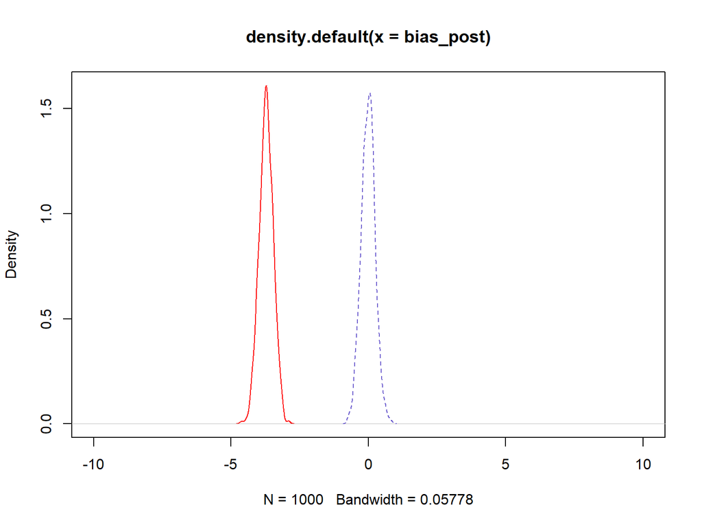

```r
plot(density(bias_post), col = "red", xlim=c(-10,10))
lines(density(bias_nopost), xlim=c(-10,10), lty = 2, col = "slateblue")
```

# Clustering

- What are SEs? Why do we care about them?
- Let’s remember our derivation of the variance estimator in OLS.
- Because $\hat{\beta} = \beta + (X'X)^{-1}X'\epsilon$
  $$\begin{align*}
  V(\hat{\beta}|X) &= V(\beta|X) + V[(X'X)^{-1}X'\epsilon|X]\\
  & = (X'X)^{-1}X'V[\epsilon|X]((X'X)^{-1}X')'\\
  & = (X'X)^{-1}X'V[\epsilon|X](X(X'X)^{-1})\\
  & = (X'X)^{-1}X'\sigma^2(X(X'X)^{-1})\\
  & = \sigma^2 (X'X)^{-1}
  \end{align*}$$
- However, there are times when we think that our errors may not be indepedent of one another but rather, correlated.

For example, some municipalities are selected (not necessarily randomly) to receive a central government-administered grant to improve water quality. A researcher thinks that benefiting from this grant may lead residents of a municipality to become more supportive of the incumbent. She surveys individuals from a number of municipalities and analyzes her study. What might be a concern arising from the normal OLS assumptions?

- Are we concerned about errors being correlated across clusters or within clusters? Why?

```r
##Individual potential outcomes

yi1 <- c(8, 10, 4, 6, 3, 2)

yi0 <- c(4, 6, 5, 7, 1, 0)

##Did the individual's municipality get the grant?

treat <- c(1, 1, 0, 0, 1, 1)

muni <- c("elkin", "elkin", "jonesville", "jonesville",
          "winston salem", "winston salem")

cluster <- as.vector(sapply(1:3, function(x) rep(x, 2)))
```

```r
muni_df <- cbind.data.frame(muni, cluster, treat, yi0, yi1)

muni_df
```

```
##            muni cluster treat yi0 yi1
## 1         elkin       1     1   4   8
## 2         elkin       1     1   6  10
## 3    jonesville       2     0   5   4
## 4    jonesville       2     0   7   6
## 5 winston salem       3     1   1   3
## 6 winston salem       3     1   0   2
```

```r
ACE <- muni_df$yi1-muni_df$yi0
```

Let’s (for now) pretend the block grants were randomly assigned to municipalities. Why might we want to cluster our standard errors here?

DGP

```r
m <- 80 # cluster size
C <- 100 # nr of clusters
N <- m*C
cl <- rep(1:C, each=m)

y_0 <- c(rnorm(N/8, 0, 2), rnorm(N/4, 3, 2), rnorm(N/4, 5, 1),
         rnorm(N/4, 7, 1), rnorm(N/8, 8, 2))
y_1 <- y_0 + rnorm(N, 3, 1)
```

What is the average causal effect?

```r
ACE <- mean(y_1) - mean(y_0)
ACE
```

```
## [1] 2.982511
```

We will assign 4000 units to treatment and 4000 to control

```r
simulation <- function(){

    simple_random <- sample(c(rep(1, N/2), rep(0, N/2)), N, replace=F)

    clusters_treat <- sample(1:C, C/2, replace=FALSE)


    g <- function(x) {sum(x==clusters_treat)}

    cluster_random <- unlist(lapply(cl, FUN=g))

    # ##Could also use a for loop.

    #cluster_random <- NA

    #for(i in 1:length(cl)){

      #cluster_random[i] <- sum(cl[i]==clusters_treat)

    #}

    # diff in means simple random assignment
    dm_sr <- mean(y_1[simple_random==1]) - mean(y_0[simple_random==0])

    # diff in means cluster assignment, individual
    dm_cl <- mean(y_1[cluster_random==1]) - mean(y_0[cluster_random==0])

    # diff in means cluster assignment, cluster means
    cl_treat <- unlist(lapply(clusters_treat, FUN=function(x) mean(y_1[cl==x])))

    cl_control <- unlist(lapply(as.vector(1:C)[-(clusters_treat)],
                                 FUN=function(x) mean(y_0[cl==x])))

    dm_cl_cl <- mean(cl_treat) - mean(cl_control)

    return(c(dm_sr, dm_cl, dm_cl_cl))

}
```

```r
simulation()
```

```
## [1] 2.929950 3.041203 3.041203
```

```r
sims <- replicate(10000, simulation())
```

How do we expect the results to look?

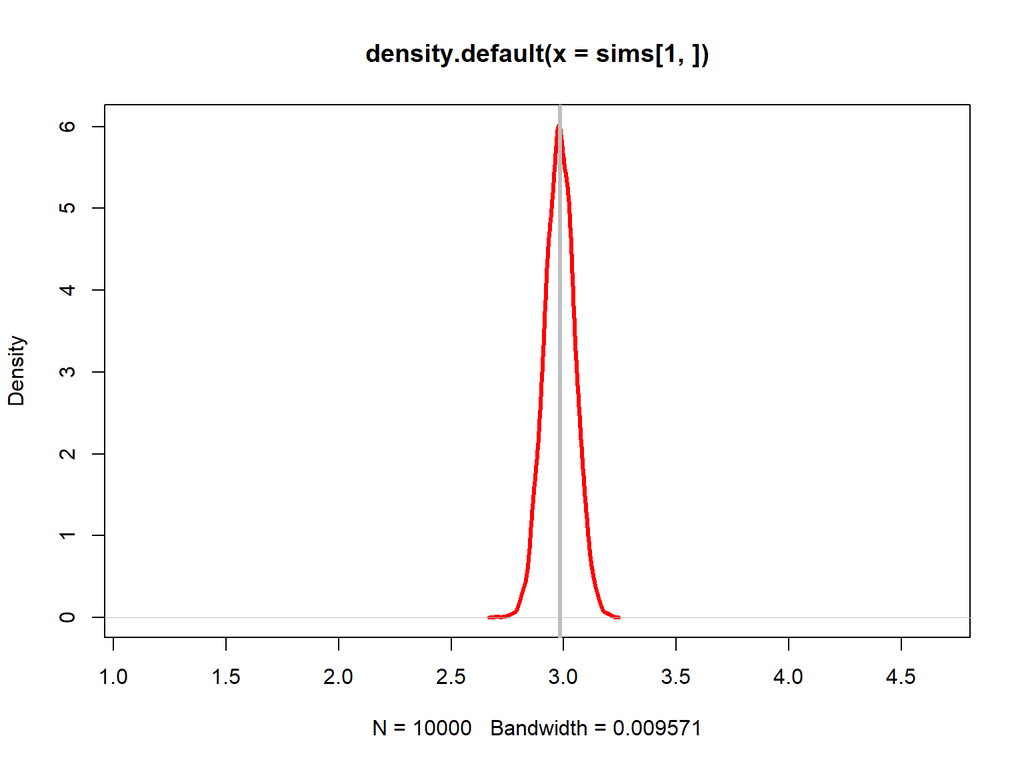

```r
plot(density(sims[1, ]), col="red", lwd=3, xlim=c(min(sims),max(sims)))
abline(v=ACE, col="grey", lwd=3)
```

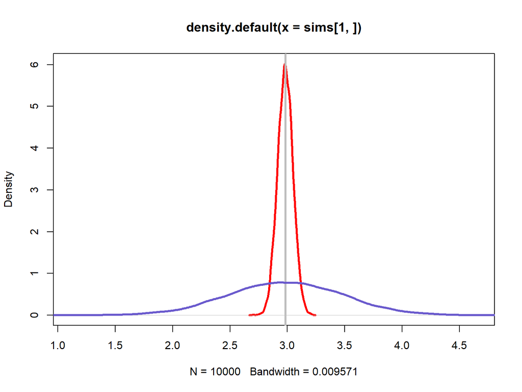

```r
plot(density(sims[1, ]), col="red", lwd=3, xlim=c(min(sims),max(sims)))
abline(v=ACE, col="grey", lwd=3)
lines(density(sims[2, ]), col="slateblue", lwd=3)
```

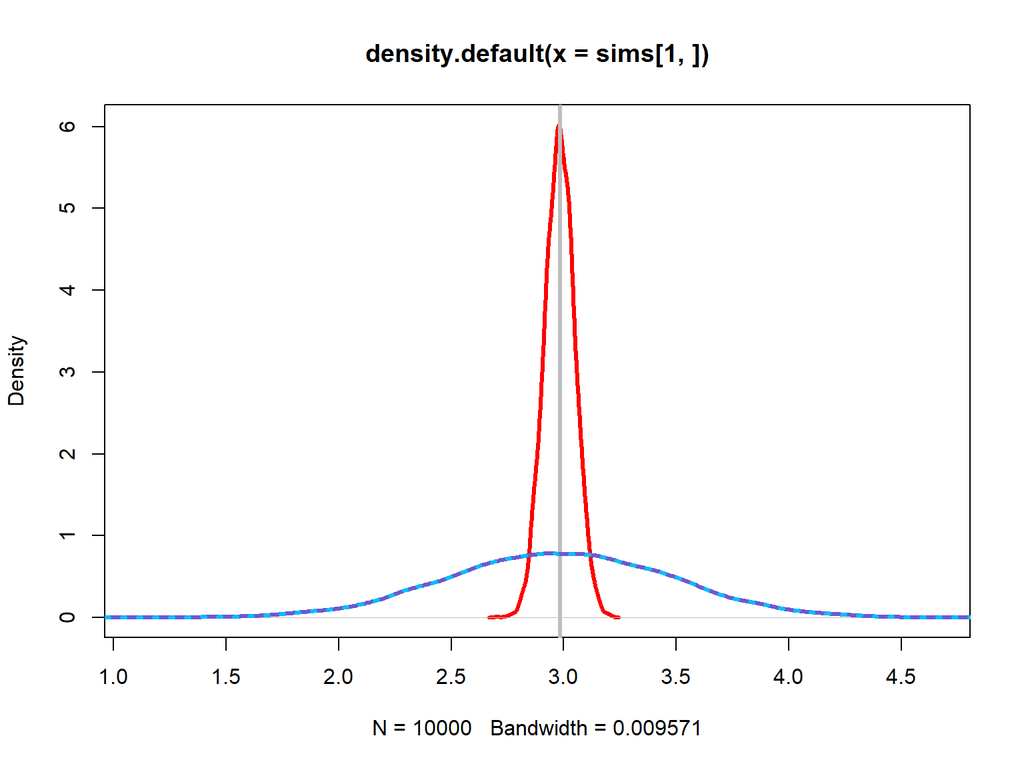

```r
plot(density(sims[1, ]), col="red", lwd=3, xlim=c(min(sims),max(sims)))
abline(v=ACE, col="grey", lwd=3)
lines(density(sims[2, ]), col="slateblue", lwd=3)
lines(density(sims[3, ]), col="deepskyblue", lwd=3, lty=3)
```

```r
apply(sims, MARGIN=1, FUN=mean)
```

```
## [1] 2.981634 2.979050 2.979050
```

```r
apply(sims, MARGIN=1, FUN=sd)
```

```
## [1] 0.06709883 0.49427756 0.49427756
```

# The problem: OLS and Heteroscedasticity

Homoskedasticity

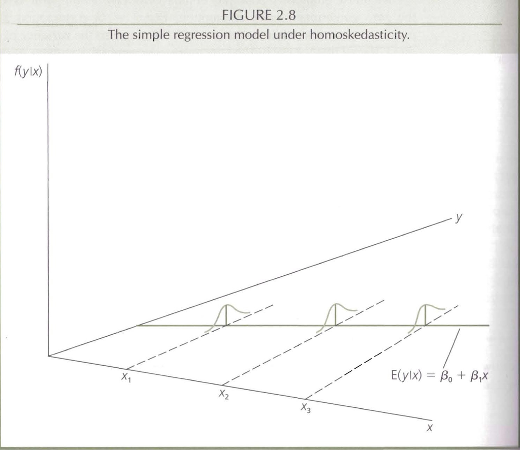

Heteroskedasticity

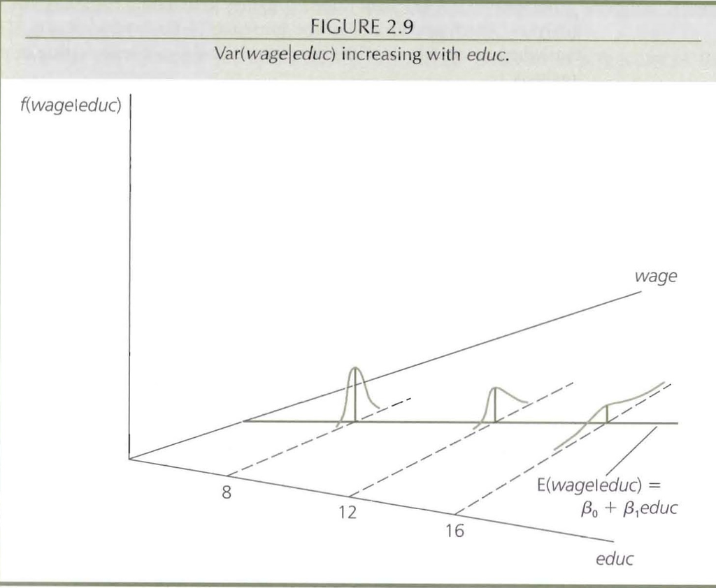

We’ll work on this more next week!

Setup

```r
y_0 <- rnorm(100, 0, 1)
y_1 <- y_0 + rnorm(100, 2, 10)

sd(y_0)
```

```
## [1] 1.032433
```

```r
sd(y_1)
```

```
## [1] 10.77153
```

```r
treat <- rbinom(100, 1, .5)
Y <- ifelse(treat==1, y_1, y_0)
```

```r
link <- "https://raw.githubusercontent.com/unc421/231b/master/Functions/t_test.R"

source(link)

ttest(Y, treat)
```

```
##       Mean 1       Mean 0   Difference      SE_Diff       t-stat
##   2.66212518  -0.12174963   2.78387481   1.53571645   1.81275314
##            N           df      p-value
## 100.00000000  42.60322183   0.07692015
```

```r
summary(lm(Y~treat))
```

```
##
## Call:
## lm(formula = Y ~ treat)
##
## Residuals:
##      Min       1Q   Median       3Q      Max
## -19.2291  -1.3867  -0.0504   1.2848  20.6217
##
## Coefficients:
##             Estimate Std. Error t value Pr(>|t|)
## (Intercept)  -0.1217     0.8756  -0.139   0.8897
## treat         2.7839     1.3353   2.085   0.0397 *
## ---
## Signif. codes:  0 '***' 0.001 '**' 0.01 '*' 0.05 '.' 0.1 ' ' 1
##
## Residual standard error: 6.611 on 98 degrees of freedom
## Multiple R-squared:  0.04247,    Adjusted R-squared:  0.0327
## F-statistic: 4.347 on 1 and 98 DF,  p-value: 0.03968
```

It will often be the case in experiments that
$$E(\epsilon|T) \not= \sigma^2$$
Indeed,
$$E(\epsilon_i|T_i=1)=Var(Y_i(1))$$
$$E(\epsilon_i|T_i=0)=Var(Y_i(0))$$
which are only equal when
$$Var(Y_i(1))=Var(Y_i(0))$$

Back to section 4. How do we calculate $SE(\hat{\beta})$ when we assume homoskedasticity?

```r
# The first thing we will need here is to build the matrix for X
X <- cbind(1, treat)

# getting the betas
betas <- solve(t(X)%*%X) %*% t(X)%*%Y

# and the residuals
e <- Y - X %*% betas

# and now we want the estimated sigma squared
hat_sigma2 <- sum(t(e)%*%e) / (nrow(X)-length(betas))

# and we can find estimated standard errors from $\hat{\sigma^2}(X'X)^{-1}$.
var_hat_beta <- hat_sigma2 * solve((t(X)%*%X)) # Why do we use * instead of %*% here?

# and get the SEs for our betas
se_hat_beta <- sqrt(diag(var_hat_beta))
se_hat_beta
```

```
##               treat
## 0.8755953 1.3352702
```